# 6 Dealing with Categorical Variables - forcats

Jiuru Lyu

2022-11-15

# Loading Packages and Data Sets

```r
library(tidyverse)
glimpse(gss_cat)
```

```
## Rows: 21,483
## Columns: 9
## $ year    <int> 2000, 2000, 2000, 2000, 2000, 2000, 2000, 2000, 2000, 2000, 20…
## $ marital <fct> Never married, Divorced, Widowed, Never married, Divorced, Mar…
## $ age     <int> 26, 48, 67, 39, 25, 25, 36, 44, 44, 47, 53, 52, 52, 51, 52, 40…
## $ race    <fct> White, White, White, White, White, White, White, White, White,…
## $ rincome <fct> $8000 to 9999, $8000 to 9999, Not applicable, Not applicable, …
## $ partyid <fct> "Ind,near rep", "Not str republican", "Independent", "Ind,near…
## $ relig   <fct> Protestant, Protestant, Protestant, Orthodox-christian, None, …
## $ denom   <fct> "Southern baptist", "Baptist-dk which", "No denomination", "No…
## $ tvhours <int> 12, NA, 2, 4, 1, NA, 3, NA, 0, 3, 2, NA, 1, NA, 1, 7, NA, 3, 3…
```

## Introudciton to `forcasts`

This package provides some tools for working with categorical variables (factors)

*Example*: find the relation between religions and average hours of watching tv.

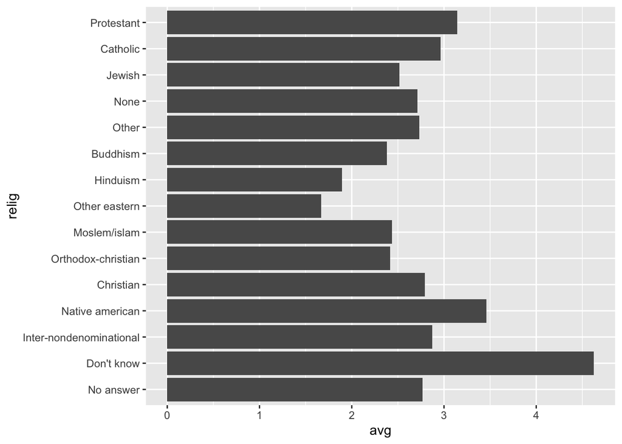

```r
relig_summary <- gss_cat %>%
  na.omit(tvhours) %>%
  group_by(relig) %>%
  summarize(avg = mean(tvhours))

ggplot(relig_summary, aes(x = relig, y = avg)) +
  geom_bar(stat = "identity") +
  coord_flip()
```

How could we interpret the plot without overall pattern? i.e., can we re-arrange this plot so that it is in descending or scending order?

## `fct_reorder()`

Reordering the levels of a factor using `fct_reorder()`.

`fct_reorder()` takes three arguments:

- f, the factor whose levels you want to modify.
- x, a numeric vector that you want to use to reorder the levels.
- Optionally, fun, a function used if there are multiple values of x for each value of f. The default value is median.

```
fct_reorder(cat, numeric)
```

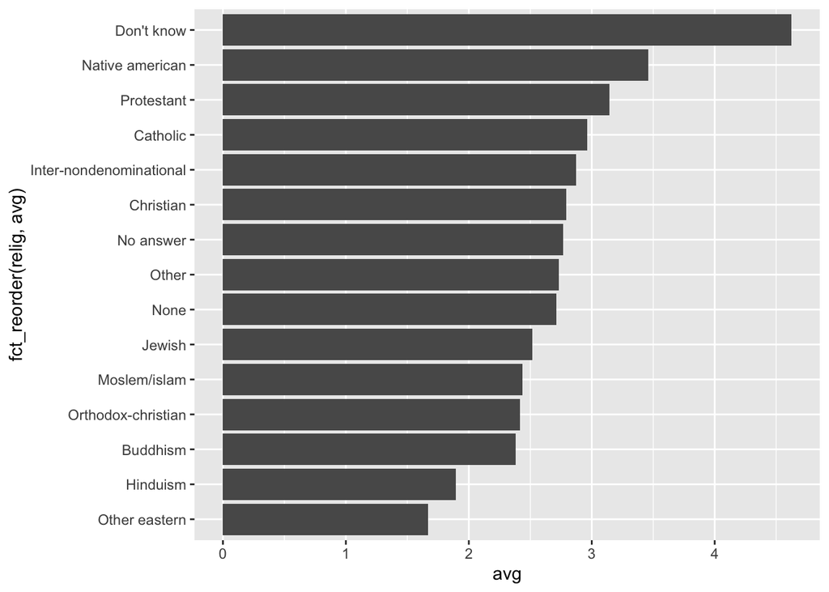

```r
relig_summary %>%
  ggplot(aes(x = avg, y = fct_reorder(relig, avg))) +
    geom_col()
```

We can use fact_rev to reverse the order of the factor.

```
fct_rev(fct_reorder(cat, numeric))
```

We can also use pip:

```
fct_reorder(cat, numeric) %>% fct_rev()
```

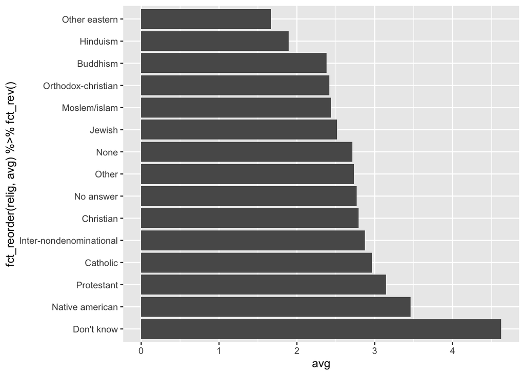

```r
relig_summary %>%
  ggplot(aes(x = avg, y = fct_reorder(relig, avg) %>% fct_rev())) +
    geom_col()
```

## `fct_relevel`

Now, we want to alwasy keep `Don't know` at the bottom of our plot, no matter we are using ascending or descending order.

You can use `fct_relevel()`. It takes a factor, f, and then any number of levels that you want to move to the front of the line (the bottom of the plot).

```
ct_relevel(cat, "level", after=)
```

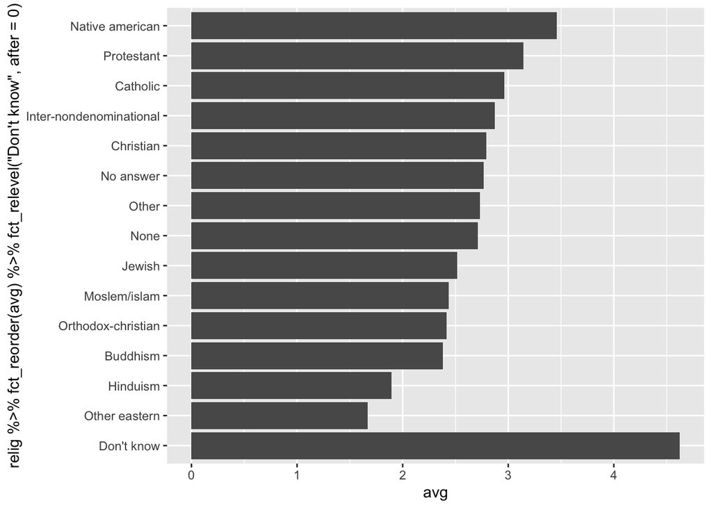

```r
relig_summary %>%
  ggplot(aes(x = avg, y = relig %>% fct_reorder(avg) %>% fct_relevel("Don't know", after = 0))) +
    geom_col()
```